# Platinum paper stats

Arthur Evans

2025-08-02

#Loading packages

```r
library(tidyverse)
library(Hmisc)
```

```r
library(corrplot)
library(forcats)
library(pscl)
library(logistf)
library(coin)
library(emmeans)
library(psych)
library(vcd)
library(DescTools)
library(corrplot)
library(ggsci)
library(RColorBrewer)
packages <- c("tidyverse", "Hmisc","corrplot", "forcats", "pscl", "logistf", "coin", "emmeans", "psych", "vcd", "DescTools", "corrplot", "ggsci", "RColorBrewer")
lapply(packages, citation)
```

[output not shown]

[output cut: 193 more lines]

[output not shown]

#Data cleaning and prep ##Importing data

```r
data <- read.csv("/Users/arthurevans/Library/Mobile Documents/com~apple~CloudDocs/Documents/Work/Research stuff/Platinum dataset stuff /Data/All platinum patients combined .csv", header = TRUE)
EMA_CO_tox <- read.csv("/Users/arthurevans/Library/Mobile Documents/com~apple~CloudDocs/Documents/Work/Research stuff/Platinum dataset stuff /Data/EMA_CO_tox_2020 - Sheet1.csv", header = TRUE)
MEA_tox <- read.csv("/Users/arthurevans/Library/Mobile Documents/com~apple~CloudDocs/Documents/Work/Research stuff/Platinum dataset stuff /Data/MEA_tox_2020 - Sheet1.csv", header = TRUE)
Carbo_2ndline_tox <- read.csv("/Users/arthurevans/Library/Mobile Documents/com~apple~CloudDocs/Documents/Work/Research stuff/Platinum dataset stuff /Data/Carboplatin_2ndline_tox_2016 - Sheet1.csv", header = TRUE)
```

##Excluding irrelevant variables and heading columns from the dataset

```r
data$Patient.no. <- NULL
data$Site.of.metastasis. <- NULL
data$Previous.chemotherapy.and.cycles. <- NULL
data$Dates. <- NULL
data$None <- NULL
data$Relevant.PMHx <- NULL
data$Reason.for.delay <- NULL
data$Was.the.dose.reduced. <- NULL
data$If.yes.by.how.much. <- NULL
data$Toxicity.and.grade <- NULL
data$Further.chemotherapy.needed.and.cycles <- NULL
data$Other.concurrent.treament. <- NULL
data$Adjuvant_chemo. <-NULL
data$CNS. <- NULL
data$HCG.at.EP.EMA.failure <- NULL
data$Patient.outcomes.and.toxicities <- NULL
data$Previous_EP.EMA <- NULL
data$Previous_TP.TE <- NULL
data$Nephropathy <- NULL
data$log_HCG.at.diagnosis..IU.L. <- log(data$HCG.at.diagnosis..IU.L.)
```

##Classifying variables

```r
data$Age.at.diagnosis <- as.numeric(data$Age.at.diagnosis)
data$Patient.no... <- as.numeric(data$Patient.no...)
data$Gravidity <- as.numeric(data$Gravidity)
data$Parity <- as.numeric(data$Parity)
data$first_platinum_treatment <- factor(data$first_platinum_treatment,
                                        levels = c("TP_TE", "EP_EMA"),
                                        labels = c("TP_TE", "EP_EMA"),
                                        ordered = FALSE)
data$first_platinum_treatment <- relevel(data$first_platinum_treatment, ref = "EP_EMA")
data$Antecedent.pregnancy. <- factor(data$Antecedent.pregnancy., levels = c("Term",
                                                                            "Complete molar pregnancy",
                                                                            "Abortion"),
                                     labels = c("Term", "Complete molar pregnancy", "Abortion"),
                                     ordered = FALSE)
data$Antecedent.pregnancy.interval..months. <- as.numeric(data$Antecedent.pregnancy.interval..months.)
data$HCG.at.diagnosis..IU.L. <- as.numeric(data$HCG.at.diagnosis..IU.L.)
data$Histology. <- factor(data$Histology., levels = c("Mixed",
                                                      "Choriocarcinoma",
                                                      "ETT",
                                                      "PSTT",
                                                      "Persistent mole"),
                          labels = c("Mixed", "Choriocarcinoma", "ETT", "PSTT", "Persistent mole"),
                          ordered = FALSE)
data$Choriocarcinoma <- factor(data$Choriocarcinoma, levels = c (0,1),
                               labels = c("no", "yes"),
                               ordered = FALSE)
data$Post.molar.GTN <- factor(data$Post.molar.GTN, levels = c (0,1),
                              labels = c("no", "yes"),
                              ordered = FALSE)
data$Placental.site.trophoblastic.tumour <- factor(data$Placental.site.trophoblastic.tumour,
                                                   levels = c (0,1),
                                                   labels = c("no", "yes"),
                                                   ordered = FALSE)
data$Epithelial.trophoblastic.tumour <- factor(data$Epithelial.trophoblastic.tumour, levels = c (0,1),
                                               labels = c("no", "yes"),
                                               ordered = FALSE)
data$Risk.score.at.diagnosis <- as.numeric(data$Risk.score.at.diagnosis)
data$Stage.at.diagnosis <- factor(data$Stage.at.diagnosis,
                                  levels = c("1", "2", "3", "4"),
                                  ordered = FALSE)
data$HCG.at.diagnosis..IU.L. <- as.numeric(data$HCG.at.diagnosis..IU.L.)
data$Lung_mets <- factor(data$Lung_mets, levels = c(0, 1),
                         labels = c("no metastasis", "metastasis"),
                         ordered = FALSE)
data$Liver_mets <- factor(data$Liver_mets,
                          levels = c(0,1),
                          labels = c("no metastasis", "metastasis"),
                          ordered = FALSE)
data$Brain_mets <- factor(data$Brain_mets,
                          levels = c(0,1),
                          labels = c("no metastasis", "metastasis"),
                          ordered = FALSE)
data$Kidney_mets <- factor(data$Kidney_mets,
                           levels = c(0,1),
                           labels = c("no metastasis", "metastasis"),
                           ordered = FALSE)
data$Spleen_mets <- factor(data$Spleen_mets,
                           levels = c(0,1),
                           labels = c("no metastasis", "metastasis"),
                           ordered = FALSE)
data$Pacreas_mets <- factor(data$Pacreas_mets,
                            levels = c(0,1),
                            labels = c("no metastasis", "metastasis"),
                            ordered = FALSE)
data$Bone_mets <- factor(data$Bone_mets,
                         levels = c(0,1),
                         labels = c("no metastasis", "metastasis"),
                         ordered = FALSE)
data$Abdo_wall_mets <- factor(data$Abdo_wall_mets,
                              levels = c(0,1),
                              labels = c("no metastasis", "metastasis"),
                              ordered = FALSE)
data$No_mets <- factor(data$No_mets,
                       levels = c(0,1),
                       labels = c("any metastasis", "no metastasis"),
                       ordered = FALSE)
data$Other_mets <- factor(data$Other_mets,
                          levels = c(0,1),
                          labels = c("no metastasis", "metastasis"),
                          ordered = FALSE)
data$Previous_EMA <- as.numeric(data$Previous_EMA)
data$Previous_EMA.CO <- as.numeric(data$Previous_EMA.CO)
data$Previous_MTX <- as.numeric(data$Previous_MTX)
data$Previous_Actinomycin.D <- as.numeric(data$Previous_Actinomycin.D)
data$Previous_Actinomycin.D.Etoposide <- as.numeric(data$Previous_Actinomycin.D.Etoposide)
data$Previous_CarboAUC24 <- as.numeric(data$Previous_CarboAUC24)
data$No_Prior_chemo <- factor(data$No_Prior_chemo,
                                 levels = c(0,1),
                                 labels = c("had_prior_chemo", "no_prior_chemo"),
                              ordered = FALSE)
data$Platinum_indication. <- factor(data$Platinum_indication.,
                                    levels = c("ETT", "relapse/refractory", "ultra-high risk", "PSTT", "HCG plateau", "Rising HCG"),
                                    ordered = FALSE)
data$Risk_score_at_platinum_start <- as.factor(data$Risk_score_at_platinum_start)
data$HCG_at_platinum_start <- as.numeric(data$HCG_at_platinum_start)
data$First_platinum_cycles <- as.numeric(data$First_platinum_cycles)
data$Cycles_of_induction_EP. <- as.factor(data$Cycles_of_induction_EP.)
data$Intra.thecal.Methotrexate.cycles <- as.factor(data$Intra.thecal.Methotrexate.cycles)
data$GCSF_given. <- factor(data$GCSF_given.,
                           levels = c("no", "yes_primary", "yes_secondary"),
                           ordered = FALSE)
data$Total.weeks.treatment.delay <- as.integer(data$Total.weeks.treatment.delay)
data$First_platinum_response. <- factor(data$First_platinum_response.,
                                        levels = c("Complete", "partial", "None"),
                                        ordered = FALSE)
data$EMA.CO <- as.numeric(data$EMA.CO)
data$Prembrolizumab <- as.numeric(data$Prembrolizumab)
data$TP.TE <- as.numeric(data$TP.TE)
data$EP <- as.factor(data$EP)
data$HD.Carbo.Etop <- as.numeric(data$HD.Carbo.Etop)
data$Carbo.paclitaxel <- as.numeric(data$Carbo.paclitaxel)
data$CTE <- as.numeric(data$CTE)
data$Cyclophosphamide <- as.numeric(data$Cyclophosphamide)
data$Capecitabine <- as.numeric(data$Capecitabine)
data$Stereotactic.Radiotherapy.needed. <- factor(data$Stereotactic.Radiotherapy.needed., level = c ("no", "yes"))
data$Alive. <- as.factor(data$Alive.)
data$If.yes.follow.up.days <- as.numeric(data$If.yes.follow.up.days)
data$HCG.at.platinum.failure <- as.numeric(data$HCG.at.platinum.failure)
data$HCG.at.platinum.failure[is.na(data$HCG.at.platinum.failure)] <- 0
data$Nausea <- factor(data$Nausea)
data$Anaemia <- factor(data$Anaemia)
data$Neutropenia <- factor(data$Neutropenia)
data$Lymphopenia <- factor(data$Lymphopenia)
data$Thrombocytopenia <- factor(data$Thrombocytopenia)
data$Neuropathy <- factor(data$Neuropathy)
data$Hair_loss <- factor(data$Hair_loss)
data$Mucositis <- factor(data$Mucositis)
data$Diarrhoea <- factor(data$Diarrhoea)
data$Constipation <- factor(data$Constipation)
data$Infection <- factor(data$Infection)
data$Skin_reaction <- factor(data$Skin_reaction)
data$Ototoxicity <- factor(data$Ototoxicity)
data$Plantar_Palmar_erythema <- factor(data$Plantar_Palmar_erythema)
data$Pleuritic_Abdo_pain <- factor(data$Pleuritic_Abdo_pain)
data$If.yes.what.surgery.and.when <- as.character(data$If.yes.what.surgery.and.when)
data$Historectomy <- factor(data$Historectomy,
                            levels = c("1", "0"),
                            labels = c("yes", "no"))
data$Resstcion.of.Mets <- factor(data$Resstcion.of.Mets,
                            levels = c("1", "0"),
                            labels = c("yes", "no"))
```

##Generating secondary variables based on the original data collected

```r
data$HCG.fall <- data$HCG_at_platinum_start - data$HCG.at.platinum.failure
data$HCG_percentage_change <- (data$HCG.fall / data$HCG_at_platinum_start ) *-100
data$hCG_at_platinum_start_scaled <- scale(data$HCG_at_platinum_start, center = TRUE, scale = TRUE)
data$Overall_patient_number <- 1:nrow(data)
data <- data %>%
  mutate(Risk_category_at_diagnosis = factor(case_when(
    `Risk.score.at.diagnosis` >= 1 & `Risk.score.at.diagnosis` <= 6  ~ "low risk",
    `Risk.score.at.diagnosis` >= 7 & `Risk.score.at.diagnosis` <= 11 ~ "high risk",
    `Risk.score.at.diagnosis` >= 13                                  ~ "ultra-high risk"),
  levels = c("low risk", "high risk", "ultra-high risk"),
  ordered = TRUE))
data$hCG_CR <- fct_collapse(data$First_platinum_response.,
                                              no = c("partial", "None"))
data$First_platinum_response. <- relevel(data$hCG_CR, ref = "no")
data$Non_term_pregnancies <- data$Gravidity - data$Parity
```

#RESULTS 4.0 ###4.1 Patient clinico-pathologic characteristics and Cisplatin regimen use cases ####Splitting dataset for various indications. Separate datasets were created for the EP/EMA and TP/TE cohorts as well as sub-data sets based on risk category and histological diagnosis.

```r
split_data <- split(data, data$first_platinum_treatment)
EP_EMA_data <- as.data.frame(split_data$EP_EMA)
TP_TE_data <- as.data.frame(split_data$TP_TE)

EP_EMA_chorio_and_moles <- EP_EMA_data %>%
  filter(Histology. %in% c("Choriocarcinoma", "Persistent mole"))

EP_EMA_UHR <- EP_EMA_data %>%
  filter(No_Prior_chemo %in% "no_prior_chemo" & Histology. %in% c("Choriocarcinoma", "Persistent mole"))

EP_EMA_refractory_patients <- EP_EMA_data %>%
  filter(No_Prior_chemo %in% "had_prior_chemo" & Histology. %in% c("Choriocarcinoma", "Persistent mole"))

TP_TE_refractory_lowrisk <- TP_TE_data %>%
  filter(Risk_category_at_diagnosis %in% c("low risk"))

TP_TE_refractory_highrisk <- TP_TE_data %>%
  filter(Risk_category_at_diagnosis %in% c("high risk"))

TP_TE_ultrahighrisk <- TP_TE_data %>%
  filter(Risk_category_at_diagnosis %in% c("ultra-high risk"))

All_chorio_and_persistent_mole <- data %>%
  filter(Histology. %in% c("Choriocarcinoma", "Persistent mole"))

TP_TE_refractory_ultrahighrisk <- All_chorio_and_persistent_mole %>%
    filter(TP.TE > 0)

EP_EMA_failed <- All_chorio_and_persistent_mole %>%
  filter(hCG_CR == "no" & first_platinum_treatment == "EP_EMA")

EP_EMA_UHR_failed <- EP_EMA_failed %>%
  filter(Risk_category_at_diagnosis == "ultra-high risk")

All_chorio_and_persistent_mole_platinum_failed <- All_chorio_and_persistent_mole %>%
  filter(hCG_CR == c("no"))


EP_EMA_UHR_lung <- EP_EMA_UHR %>%
  filter(Lung_mets == "metastasis")
EP_EMA_refractory_patients_lung <- EP_EMA_refractory_patients %>%
  filter(Lung_mets == "metastasis")
EP_EMA_UHR_liver <- EP_EMA_UHR %>%
  filter(Liver_mets == "metastasis")
EP_EMA_refractory_patients_liver <- EP_EMA_refractory_patients %>%
  filter(Liver_mets == "metastasis")
EP_EMA_UHR_brain <- EP_EMA_UHR %>%
  filter(Brain_mets == "metastasis")
EP_EMA_refractory_patients_brain <- EP_EMA_refractory_patients %>%
  filter(Brain_mets == "metastasis")

EP_EMA_liver_or_brain_mets <- All_chorio_and_persistent_mole %>%
  filter((Liver_mets == "metastasis" | Brain_mets == "metastasis") & first_platinum_treatment == "EP_EMA")

TP_TE_liver_or_brain_mets <- All_chorio_and_persistent_mole %>%
  filter((Liver_mets == "metastasis" | Brain_mets == "metastasis") & first_platinum_treatment == "TP_TE")

TP_TE_refractory_lowrisk_lung <- TP_TE_refractory_lowrisk %>%
  filter(Lung_mets == "metastasis")
TP_TE_refractory_highrisk_lung <- TP_TE_refractory_highrisk %>%
  filter(Lung_mets == "metastasis")
TP_TE_refractory_lowrisk_liver <- TP_TE_refractory_lowrisk %>%
  filter(Liver_mets == "metastasis")
TP_TE_refractory_highrisk_liver <- TP_TE_refractory_highrisk %>%
  filter(Liver_mets == "metastasis")
TP_TE_refractory_lowrisk_brain <- TP_TE_refractory_lowrisk %>%
  filter(Brain_mets == "metastasis")
TP_TE_refractory_highrisk_brain <- TP_TE_refractory_highrisk %>%
  filter(Brain_mets == "metastasis")
TP_TE_ultrahighrisk_lung <- TP_TE_ultrahighrisk %>%
  filter(Lung_mets == "metastasis")
TP_TE_ultrahighrisk_liver <- TP_TE_ultrahighrisk %>%
  filter(Liver_mets == "metastasis")
TP_TE_ultrahighrisk_brain <- TP_TE_ultrahighrisk %>%
  filter(Brain_mets == "metastasis")

Further_surgery_patients <- All_chorio_and_persistent_mole %>%
  filter(Further.surgery.needed. == "yes")
```

####Investigating correlations between patient characteristics and treamtent received

```r
t.test(Age.at.diagnosis ~ first_platinum_treatment, data = All_chorio_and_persistent_mole)
```

```
##
##  Welch Two Sample t-test
##
## data:  Age.at.diagnosis by first_platinum_treatment
## t = -1.106, df = 19.547, p-value = 0.2821
## alternative hypothesis: true difference in means between group EP_EMA and group TP_TE is not equal to 0
## 95 percent confidence interval:
##  -9.24416  2.84416
## sample estimates:
## mean in group EP_EMA  mean in group TP_TE
##             35.06667             38.26667
```

```r
t.test(Risk.score.at.diagnosis ~ first_platinum_treatment, data = All_chorio_and_persistent_mole)
```

```
##
##  Welch Two Sample t-test
##
## data:  Risk.score.at.diagnosis by first_platinum_treatment
## t = 3.599, df = 27.954, p-value = 0.00122
## alternative hypothesis: true difference in means between group EP_EMA and group TP_TE is not equal to 0
## 95 percent confidence interval:
##  2.469893 8.996773
## sample estimates:
## mean in group EP_EMA  mean in group TP_TE
##             13.33333              7.60000
```

```r
wilcox.test(HCG.at.diagnosis..IU.L.~ first_platinum_treatment, data = All_chorio_and_persistent_mole)
```

```
##
##  Wilcoxon rank sum exact test
##
## data:  HCG.at.diagnosis..IU.L. by first_platinum_treatment
## W = 84, p-value = 0.3766
## alternative hypothesis: true location shift is not equal to 0
```

```r
wilcox.test(Antecedent.pregnancy.interval..months. ~ first_platinum_treatment, data = All_chorio_and_persistent_mole)
```

```
##
##  Wilcoxon rank sum test with continuity correction
##
## data:  Antecedent.pregnancy.interval..months. by first_platinum_treatment
## W = 65, p-value = 0.5879
## alternative hypothesis: true location shift is not equal to 0
```

```r
cor.test(TP_TE_data$mean_tox_burden,TP_TE_data$Age.at.diagnosis, method = "pearson")
```

```
##
##  Pearson's product-moment correlation
##
## data:  TP_TE_data$mean_tox_burden and TP_TE_data$Age.at.diagnosis
## t = 0.0078494, df = 11, p-value = 0.9939
## alternative hypothesis: true correlation is not equal to 0
## 95 percent confidence interval:
##  -0.5493350  0.5526314
## sample estimates:
##         cor
## 0.002366685
```

```r
cor.test(EP_EMA_chorio_and_moles$mean_tox_burden,EP_EMA_chorio_and_moles$Age.at.diagnosis, method = "pearson")
```

```
##
##  Pearson's product-moment correlation
##
## data:  EP_EMA_chorio_and_moles$mean_tox_burden and EP_EMA_chorio_and_moles$Age.at.diagnosis
## t = 1.7061, df = 12, p-value = 0.1137
## alternative hypothesis: true correlation is not equal to 0
## 95 percent confidence interval:
##  -0.1159377  0.7877376
## sample estimates:
##     cor
## 0.44182
```

```r
Antecendent_pregnancy_type_fisher_test_table <- table(All_chorio_and_persistent_mole$first_platinum_treatment, All_chorio_and_persistent_mole$Antecedent.pregnancy.)
fisher.test(Antecendent_pregnancy_type_fisher_test_table)
```

```
##
##  Fisher's Exact Test for Count Data
##
## data:  Antecendent_pregnancy_type_fisher_test_table
## p-value = 0.6048
## alternative hypothesis: two.sided
```

```r
Lung_mets_fisher_test_table <- table(All_chorio_and_persistent_mole$first_platinum_treatment, All_chorio_and_persistent_mole$Lung_mets)
fisher.test(Lung_mets_fisher_test_table)
```

```
##
##  Fisher's Exact Test for Count Data
##
## data:  Lung_mets_fisher_test_table
## p-value = 0.3295
## alternative hypothesis: true odds ratio is not equal to 1
## 95 percent confidence interval:
##  0.003734179 2.488679819
## sample estimates:
## odds ratio
##  0.2067394
```

```r
Liver_mets_fisher_test_table <- table(All_chorio_and_persistent_mole$first_platinum_treatment, All_chorio_and_persistent_mole$Liver_mets)
fisher.test(Liver_mets_fisher_test_table)
```

```
##
##  Fisher's Exact Test for Count Data
##
## data:  Liver_mets_fisher_test_table
## p-value = 0.08008
## alternative hypothesis: true odds ratio is not equal to 1
## 95 percent confidence interval:
##  0.002183889 1.190995284
## sample estimates:
## odds ratio
##  0.1151766
```

```r
Brain_mets_fisher_test_table <- table(All_chorio_and_persistent_mole$first_platinum_treatment, All_chorio_and_persistent_mole$Brain_mets)
fisher.test(Brain_mets_fisher_test_table)
```

```
##
##  Fisher's Exact Test for Count Data
##
## data:  Brain_mets_fisher_test_table
## p-value = 0.000484
## alternative hypothesis: true odds ratio is not equal to 1
## 95 percent confidence interval:
##  0.0005721542 0.3109310038
## sample estimates:
## odds ratio
## 0.03071799
```

####Investigating dataset wide correlations for help selecting variabls for future modeling

```r
df <- All_chorio_and_persistent_mole
numeric_variables <- names(df)[sapply(df, is.numeric)]
numeric_variables <- numeric_variables[sapply(df[numeric_variables], function(x) sd(x, na.rm = TRUE) > 0)]
factor_variables <- names(df)[sapply(df, is.factor)]
all_variables <- c(numeric_variables, factor_variables)
factor_variables <- factor_variables[sapply(df[factor_variables], function(x) nlevels(x) > 1)]
vars <- c(numeric_variables, factor_variables)


numeric_numeric_association <- function(x, y) {
  valid_idx <- !is.na(x) & !is.na(y)
  x <- x[valid_idx]
  y <- y[valid_idx]
  if (length(unique(x)) < 2 | length(unique(y)) < 2) return(NA)
  cor(x, y, method = "spearman")
}
factor_factor_association <- function(x, y) {
  valid_idx <- !is.na(x) & !is.na(y)
  x <- droplevels(x[valid_idx])
  y <- droplevels(y[valid_idx])
  if (nlevels(x) < 2 | nlevels(y) < 2) return(NA)
  vcd::assocstats(table(x, y))$cramer
}
numeric_factor_association <- function(num, cat) {
  valid_idx <- !is.na(num) & !is.na(cat)
  num <- num[valid_idx]
  cat <- droplevels(cat[valid_idx])  # <-- THIS is the key
  if (nlevels(cat) < 2 | length(unique(num)) < 2) return(NA)
  DescTools::EtaSq(aov(num ~ cat), type = 1)[1, "eta.sq"]
}


correlation_matrix <- matrix(NA, nrow = length(vars), ncol = length(vars))
rownames(correlation_matrix) <- vars
colnames(correlation_matrix) <- vars

for (i in vars) {
  for (j in vars) {
    if (i == j) {
      correlation_matrix[i, j] <- 1
    }
    else if (i %in% numeric_variables & j %in% numeric_variables) {
      correlation_matrix[i, j] <- numeric_numeric_association(df[[i]], df[[j]])
    }
    else if (i %in% factor_variables & j %in% factor_variables) {
      correlation_matrix[i, j] <- factor_factor_association(df[[i]], df[[j]])
    }
    else if (i %in% numeric_variables & j %in% factor_variables) {
      correlation_matrix[i, j] <- numeric_factor_association(df[[i]], df[[j]])
    }
    else if (i %in% factor_variables & j %in% numeric_variables) {
      correlation_matrix[i, j] <- numeric_factor_association(df[[j]], df[[i]])
    }
  }
}
```

```r
png("dataset_wide_correlation_plot.png", width = 10, height = 10, units = "in", res = 300)
corrplot(
  correlation_matrix,
  method = "color",
  type = "upper",
  tl.col = "black",
  tl.cex = 0.3,
  tl.srt = 45,
  na.label = " "
)
dev.off()
```

##4.2 Toxicity profile and weighted toxicity score ####Re-labelling all the toxicity data as numeric to allow for calculation

```r
data$Nausea <- as.integer(data$Nausea)
data$Anaemia <- as.integer(data$Anaemia)
data$Neutropenia <- as.integer(data$Neutropenia)
data$Lymphopenia <- as.integer(data$Lymphopenia)
data$Thrombocytopenia <- as.integer(data$Thrombocytopenia)
data$Total_haem_burden <- as.integer(data$Total_haem_burden)
data$Neuropathy <- as.integer(data$Neuropathy)
data$Hair_loss <- as.integer(data$Hair_loss)
data$Mucositis <- as.integer(data$Mucositis)
data$Diarrhoea <- as.integer(data$Diarrhoea)
data$Constipation <- as.integer(data$Constipation)
data$Infection <- as.integer(data$Infection)
data$Skin_reaction <- as.integer(data$Skin_reaction)
data$Ototoxicity <- as.integer(data$Ototoxicity)
data$Plantar_Palmar_erythema <- as.integer(data$Plantar_Palmar_erythema)
data$Pleuritic_Abdo_pain <- as.integer(data$Pleuritic_Abdo_pain)
data$Total_tox_burden <- as.integer(data$Total_tox_burden)
data$mean_tox_burden <- as.numeric(data$mean_tox_burden)
data$mean_haem_burden <- as.numeric(data$mean_haem_burden)
```

####Extracting only the toxicity data from each sub dataset

```r
TP_TE_Toxicity_data <- TP_TE_data %>%
  select(Patient.no...,Nausea, Anaemia, Neutropenia, Lymphopenia, Thrombocytopenia, Neuropathy, Hair_loss, Mucositis, Diarrhoea, Constipation, Infection, Skin_reaction, Ototoxicity, Plantar_Palmar_erythema, Pleuritic_Abdo_pain)

EP_EMA_chorio_and_moles_Toxicity_data <- EP_EMA_chorio_and_moles %>%
  select(Patient.no...,Nausea, Anaemia, Neutropenia, Lymphopenia, Thrombocytopenia, Neuropathy, Hair_loss, Mucositis, Diarrhoea, Constipation, Infection, Skin_reaction, Ototoxicity, Plantar_Palmar_erythema, Pleuritic_Abdo_pain)
```

####Now I am extracting each toxicity and the percentage of patietns that experienced it at each grade

```r
data_long <- TP_TE_Toxicity_data %>%
  pivot_longer(cols = -Patient.no..., names_to = "Toxicity", values_to = "grade")
combined_tox_summary_table <- data_long %>%
  group_by(Toxicity, grade) %>%
  summarise(count = n(), .groups = 'drop') %>%
  group_by(Toxicity) %>%
  mutate(percentage = count / sum(count)) %>%
  ungroup() %>%
  select(-count)
TP_TE_tox_summary_table_reshaped <- combined_tox_summary_table %>%
  pivot_wider(names_from = grade, values_from = percentage, values_fill = list(percentage = 0)) %>%
  rename_with(~ paste0("Grade_", .), -Toxicity)
TP_TE_tox_summary_table_reshaped <- TP_TE_tox_summary_table_reshaped %>%
  arrange(Toxicity)
TP_TE_tox_summary_table_reshaped$Grade_0 <- as.numeric(TP_TE_tox_summary_table_reshaped$Grade_0)
TP_TE_tox_summary_table_reshaped$Grade_1 <- as.numeric(TP_TE_tox_summary_table_reshaped$Grade_1)
TP_TE_tox_summary_table_reshaped$Grade_2 <- as.numeric(TP_TE_tox_summary_table_reshaped$Grade_2)
TP_TE_tox_summary_table_reshaped$Grade_3 <- as.numeric(TP_TE_tox_summary_table_reshaped$Grade_3)
TP_TE_tox_summary_table_reshaped$Grade_4 <- replicate(15,0)
print(TP_TE_tox_summary_table_reshaped)
```

```
## # A tibble: 15 × 6
##    Toxicity                Grade_0 Grade_1 Grade_2 Grade_3 Grade_4
##    <chr>                     <dbl>   <dbl>   <dbl>   <dbl>   <dbl>
##  1 Anaemia                   0.6    0.333   0.0667     0         0
##  2 Constipation              0.267  0.2     0.533      0         0
##  3 Diarrhoea                 0.667  0.333   0          0         0
##  4 Hair_loss                 0      0       1          0         0
##  5 Infection                 0.867  0.0667  0.0667     0         0
##  6 Lymphopenia               0.933  0       0.0667     0         0
##  7 Mucositis                 0.467  0.4     0.133      0         0
##  8 Nausea                    0.533  0.4     0.0667     0         0
##  9 Neuropathy                0.333  0.333   0.133      0.2       0
## 10 Neutropenia               0.933  0.0667  0          0         0
## 11 Ototoxicity               0.667  0.0667  0.267      0         0
## 12 Plantar_Palmar_erythema   0.933  0.0667  0          0         0
## 13 Pleuritic_Abdo_pain       0.867  0.133   0          0         0
## 14 Skin_reaction             0.8    0.2     0          0         0
## 15 Thrombocytopenia          1      0       0          0         0
```

```r
data_long <- EP_EMA_chorio_and_moles_Toxicity_data %>%
  pivot_longer(cols = -Patient.no..., names_to = "Toxicity", values_to = "grade")
combined_tox_summary_table <- data_long %>%
  group_by(Toxicity, grade) %>%
  summarise(count = n(), .groups = 'drop') %>%
  group_by(Toxicity) %>%
  mutate(percentage = count / sum(count)) %>%
  ungroup() %>%
  select(-count)
EP_EMA_chorio_and_moles_tox_summary_table_reshaped <- combined_tox_summary_table %>%
  pivot_wider(names_from = grade, values_from = percentage, values_fill = list(percentage = 0)) %>%
  rename_with(~ paste0("Grade_", .), -Toxicity)
EP_EMA_chorio_and_moles_tox_summary_table_reshaped <- EP_EMA_chorio_and_moles_tox_summary_table_reshaped %>%
  arrange(Toxicity)
EP_EMA_chorio_and_moles_tox_summary_table_reshaped$Grade_0 <- as.numeric(EP_EMA_chorio_and_moles_tox_summary_table_reshaped$Grade_0)
EP_EMA_chorio_and_moles_tox_summary_table_reshaped$Grade_1 <- as.numeric(EP_EMA_chorio_and_moles_tox_summary_table_reshaped$Grade_1)
EP_EMA_chorio_and_moles_tox_summary_table_reshaped$Grade_2 <- as.numeric(EP_EMA_chorio_and_moles_tox_summary_table_reshaped$Grade_2)
EP_EMA_chorio_and_moles_tox_summary_table_reshaped$Grade_3 <- as.numeric(EP_EMA_chorio_and_moles_tox_summary_table_reshaped$Grade_3)
EP_EMA_chorio_and_moles_tox_summary_table_reshaped$Grade_4 <- as.numeric(EP_EMA_chorio_and_moles_tox_summary_table_reshaped$Grade_4)
print(EP_EMA_chorio_and_moles_tox_summary_table_reshaped)
```

```
## # A tibble: 15 × 6
##    Toxicity                Grade_0 Grade_1 Grade_2 Grade_3 Grade_4
##    <chr>                     <dbl>   <dbl>   <dbl>   <dbl>   <dbl>
##  1 Anaemia                   0.133  0.133   0.467   0.267      0
##  2 Constipation              0.333  0.0667  0.6     0          0
##  3 Diarrhoea                 0.733  0.2     0.0667  0          0
##  4 Hair_loss                 0      0       1       0          0
##  5 Infection                 0.467  0.2     0.267   0.0667     0
##  6 Lymphopenia               0.333  0.133   0.333   0.2        0
##  7 Mucositis                 0.333  0.0667  0.267   0.333      0
##  8 Nausea                    0.333  0.467   0.2     0          0
##  9 Neuropathy                0.467  0.2     0.133   0.2        0
## 10 Neutropenia               0.2    0.0667  0       0.333      0.4
## 11 Ototoxicity               0.4    0.0667  0.467   0.0667     0
## 12 Plantar_Palmar_erythema   0.8    0.0667  0.133   0          0
## 13 Pleuritic_Abdo_pain       0.667  0.267   0.0667  0          0
## 14 Skin_reaction             0.733  0.267   0       0          0
## 15 Thrombocytopenia          0.533  0.133   0       0.333      0
```

####Specifying the weighting for each toxicity and grade

```r
Toxicity_weights <- data.frame(
  Toxicity = c("Nausea", "Anaemia", "Neutropenia", "Lymphopenia", "Thrombocytopenia", "Neuropathy", "Hair_loss","Mucositis", "Diarrhoea", "Constipation", "Infection", "Skin_reaction", "Ototoxicity", "Plantar_Palmar_erythema", "Pleuritic_Abdo_pain"),
  Grade_0 = c("0","0","0","0","0","0","0","0","0","0","0","0","0","0","0"),
  Grade_1 = c("4","2","0","4","4","8","8","4","4","4","4","0","8","8","8"),
  Grade_2 = c("8","4","0","8","8","16","16","8","8","8","8","16","32","16","16"),
  Grade_3 = c("32","8","16","32","32","32","0","32","16","16","32","32","64","32","32"),
  Grade_4 = c("0","32","32","64","64","64","0","0","32","64","64","64","0","0","0"))
Toxicity_weights <- Toxicity_weights %>%
  arrange(Toxicity)
print(Toxicity_weights)
```

```
##                   Toxicity Grade_0 Grade_1 Grade_2 Grade_3 Grade_4
## 1                  Anaemia       0       2       4       8      32
## 2             Constipation       0       4       8      16      64
## 3                Diarrhoea       0       4       8      16      32
## 4                Hair_loss       0       8      16       0       0
## 5                Infection       0       4       8      32      64
## 6              Lymphopenia       0       4       8      32      64
## 7                Mucositis       0       4       8      32       0
## 8                   Nausea       0       4       8      32       0
## 9               Neuropathy       0       8      16      32      64
## 10             Neutropenia       0       0       0      16      32
## 11             Ototoxicity       0       8      32      64       0
## 12 Plantar_Palmar_erythema       0       8      16      32       0
## 13     Pleuritic_Abdo_pain       0       8      16      32       0
## 14           Skin_reaction       0       0      16      32      64
## 15        Thrombocytopenia       0       4       8      32      64
```

```r
write.csv(Toxicity_weights, '/Users/arthurevans/Library/Mobile Documents/com~apple~CloudDocs/Documents/Work/Research stuff/Platinum dataset stuff /Data/Toxicity_weights.csv', row.names = FALSE)
Toxicity_weights$Grade_0 <- as.numeric(Toxicity_weights$Grade_0)
Toxicity_weights$Grade_1 <- as.numeric(Toxicity_weights$Grade_1)
Toxicity_weights$Grade_2 <- as.numeric(Toxicity_weights$Grade_2)
Toxicity_weights$Grade_3 <- as.numeric(Toxicity_weights$Grade_3)
Toxicity_weights$Grade_4 <- as.numeric(Toxicity_weights$Grade_4)
```

####Now that the percentage spread of each toxicity and the weighting of each to toxicity have been specified I can calculate the actual WTS for each cohort

```r
EP_EMA_chorio_and_moles_tox_weighted <- cbind(
  Toxicity = EP_EMA_chorio_and_moles_tox_summary_table_reshaped$Toxicity,
  as.data.frame(Map(`*`,
    EP_EMA_chorio_and_moles_tox_summary_table_reshaped %>% select(-Toxicity),
    Toxicity_weights %>% select(-Toxicity))))
EP_EMA_chorio_and_moles_wts <- sum(unlist(EP_EMA_chorio_and_moles_tox_weighted %>% select(-Toxicity)))
print(EP_EMA_chorio_and_moles_wts)
```

```
## [1] 122.9333
```

```r
TP_TE_tox_weighted <- cbind(
  Toxicity = TP_TE_tox_summary_table_reshaped$Toxicity,
  as.data.frame(Map(`*`,
    TP_TE_tox_summary_table_reshaped %>% select(-Toxicity),
    Toxicity_weights %>% select(-Toxicity))))
TP_TE_wts <- sum(unlist(TP_TE_tox_weighted %>% select(-Toxicity)))
print(TP_TE_wts)
```

```
## [1] 51.33333
```

####Figure 2a&b

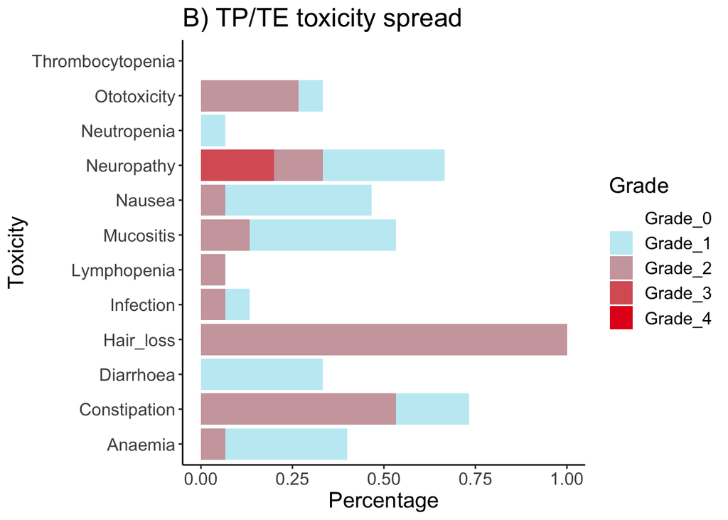

```r
Excluded_toxiciites <- c("Pleuritic_Abdo_pain", "Plantar_Palmar_erythema", "Skin_reaction")

tox_cols <- colorRampPalette(c("#C3ECF4","#E41A1C"))(4)
tox_cols_labels <- c("Grade_0" = "#FFFFFF00",
                     "Grade_1"= tox_cols[1],
                     "Grade_2"= tox_cols[2],
                     "Grade_3"= tox_cols[3],
                     "Grade_4"= tox_cols[4])



TP_TE_tox_spread_data <- as.data.frame(TP_TE_tox_summary_table_reshaped, row.names = TRUE)
TP_TE_tox_spread_data <- TP_TE_tox_spread_data %>%
  filter(!Toxicity %in% Excluded_toxiciites)
TP_TE_tox_spread_data_long <- TP_TE_tox_spread_data %>%
  pivot_longer(cols = starts_with("Grade_"),
               names_to = "Grade",
               values_to = "Percentage")
TP_TE_tox_spread_plot <- ggplot(TP_TE_tox_spread_data_long, aes(x= Toxicity, y = Percentage, fill = Grade)) +
  geom_bar(stat = "identity", position = "stack") +
  scale_fill_manual(values = tox_cols_labels) +
  theme_classic() +
  theme(text = element_text(size = 15)) +
  coord_flip()+
  ggtitle("B) TP/TE toxicity spread")
print(TP_TE_tox_spread_plot)
```

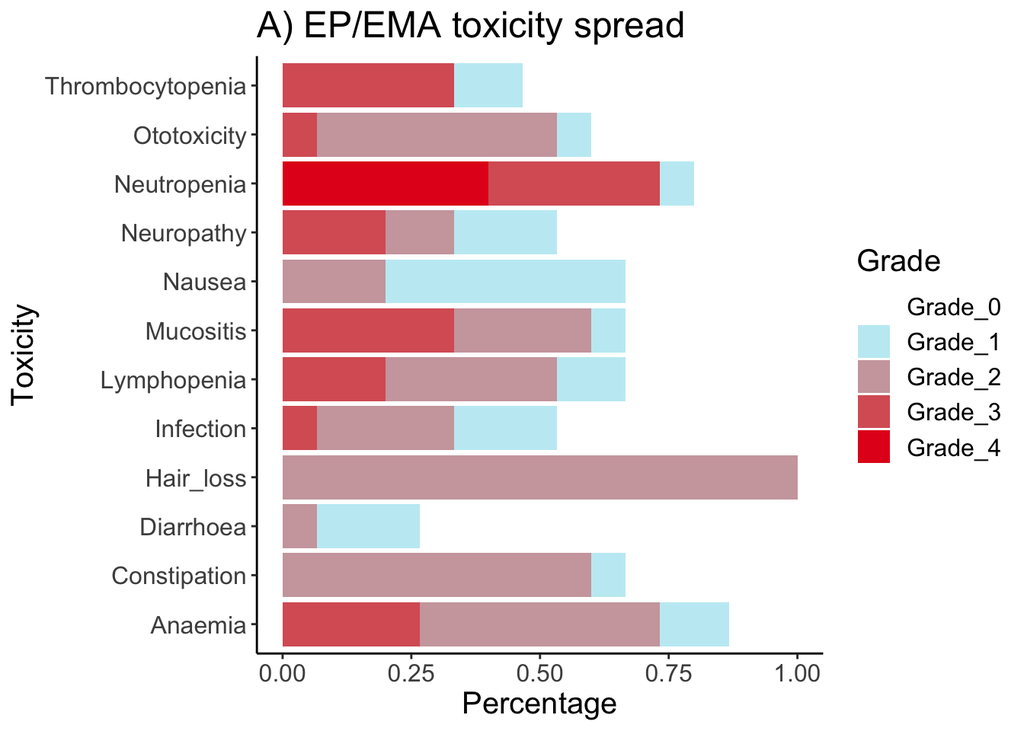

```r
ggsave("TP_TE_tox_spread_plot.png", plot = TP_TE_tox_spread_plot, width = 7, height = 4, dpi = 300)




EP_EMA_chorio_and_moles_tox_spread_data <- as.data.frame(EP_EMA_chorio_and_moles_tox_summary_table_reshaped, row.names = TRUE)
EP_EMA_chorio_and_moles_tox_spread_data <- EP_EMA_chorio_and_moles_tox_spread_data %>%
  filter(!Toxicity %in% Excluded_toxiciites)
EP_EMA_chorio_and_moles_tox_spread_data_long <- EP_EMA_chorio_and_moles_tox_spread_data %>%
  pivot_longer(cols = starts_with("Grade_"),
               names_to = "Grade",
               values_to = "Percentage")
EP_EMA_chorio_and_moles_tox_spread_plot <- ggplot(EP_EMA_chorio_and_moles_tox_spread_data_long, aes(x= Toxicity, y = Percentage, fill = Grade)) +
  geom_bar(stat = "identity", position = "stack") +
  scale_fill_manual(values = tox_cols_labels) +
  theme_classic() +
  theme(
    text = element_text(size = 15)) +
  coord_flip() +
  ggtitle("A) EP/EMA toxicity spread")
print(EP_EMA_chorio_and_moles_tox_spread_plot)
```

```r
ggsave("EP_EMA_chorio_and_moles_tox_spread_plot.png", plot = EP_EMA_chorio_and_moles_tox_spread_plot, width =7, height =4, dpi = 300)
```

####Predictive factors of toxicity response

```r
relevel(All_chorio_and_persistent_mole$first_platinum_treatment, "EP_EMA")
```

```
##  [1] TP_TE  EP_EMA EP_EMA EP_EMA TP_TE  EP_EMA EP_EMA TP_TE  TP_TE  TP_TE
## [11] EP_EMA TP_TE  TP_TE  EP_EMA EP_EMA EP_EMA EP_EMA EP_EMA EP_EMA EP_EMA
## [21] TP_TE  EP_EMA TP_TE  TP_TE  TP_TE  TP_TE  TP_TE  TP_TE  EP_EMA TP_TE
## Levels: EP_EMA TP_TE
```

```r
platinum_toxicity_comparison <- glm(mean_tox_burden ~
                                      Risk.score.at.diagnosis +
                                      Age.at.diagnosis +
                                      Stage.at.diagnosis +
                                      first_platinum_treatment,
                                    data = All_chorio_and_persistent_mole,
                                    family = gaussian)
summary(platinum_toxicity_comparison)
```

```
##
## Call:
## glm(formula = mean_tox_burden ~ Risk.score.at.diagnosis + Age.at.diagnosis +
##     Stage.at.diagnosis + first_platinum_treatment, family = gaussian,
##     data = All_chorio_and_persistent_mole)
##
## Coefficients:
##                                Estimate Std. Error t value Pr(>|t|)
## (Intercept)                    0.764977   0.376606   2.031   0.0557 .
## Risk.score.at.diagnosis       -0.018591   0.024128  -0.771   0.4500
## Age.at.diagnosis               0.003258   0.010156   0.321   0.7517
## Stage.at.diagnosis2            0.080737   0.365174   0.221   0.8273
## Stage.at.diagnosis3            0.169879   0.254775   0.667   0.5125
## Stage.at.diagnosis4            0.033466   0.333140   0.100   0.9210
## first_platinum_treatmentTP_TE -0.401574   0.179210  -2.241   0.0365 *
## ---
## Signif. codes:  0 '***' 0.001 '**' 0.01 '*' 0.05 '.' 0.1 ' ' 1
##
## (Dispersion parameter for gaussian family taken to be 0.09353694)
##
##     Null deviance: 2.4420  on 26  degrees of freedom
## Residual deviance: 1.8707  on 20  degrees of freedom
##   (3 observations deleted due to missingness)
## AIC: 20.546
##
## Number of Fisher Scoring iterations: 2
```

```r
BIC(platinum_toxicity_comparison)
```

```
## [1] 30.91278
```

```r
logLik(platinum_toxicity_comparison)
```

```
## 'log Lik.' -2.273045 (df=8)
```

```r
pR2(platinum_toxicity_comparison)
```

```
## fitting null model for pseudo-r2
```

```
##        llh    llhNull         G2   McFadden       r2ML       r2CU
## -2.2730445 -5.8703941  7.1946992  0.6127952  0.2339213  0.6633536
```

####Figure 2c,d,&e

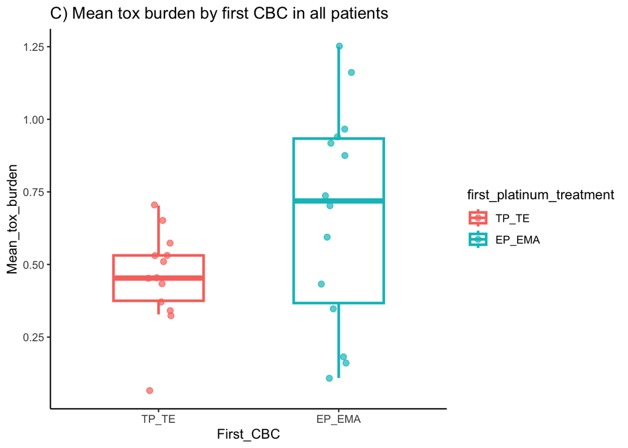

```r
All_chorio_and_persistent_mole$first_platinum_treatment <-
  factor(All_chorio_and_persistent_mole$first_platinum_treatment,
         levels = rev(levels(All_chorio_and_persistent_mole$first_platinum_treatment)))

Mean_toxicity_burden_plot <- ggplot(All_chorio_and_persistent_mole,
                                    aes(x = first_platinum_treatment,
                                        y = mean_tox_burden,
                                        colour = first_platinum_treatment)) +
  geom_boxplot(outlier.shape = NA, width = 0.5, size = 1) +
  geom_jitter(width = 0.1, alpha = 0.7, size = 2) +
  labs(x = "First_CBC",
       y = "Mean_tox_burden",
       title = "C) Mean tox burden by first CBC in all patients") +
  theme_classic() + theme(legend.position = "right")
print(Mean_toxicity_burden_plot)
```

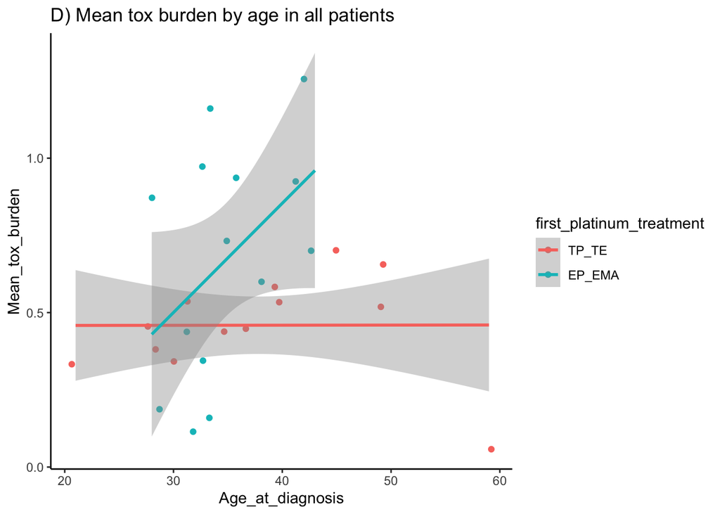

```r
ggsave("Mean_toxicity_burden_plot.png", plot = Mean_toxicity_burden_plot, width = 6, height = 4, dpi = 300)
Mean_toxicity_burden_by_age_plot <- All_chorio_and_persistent_mole%>% ggplot(aes(x= Age.at.diagnosis, y= mean_tox_burden, hwy, colour = first_platinum_treatment))  +
  geom_jitter() +
  geom_smooth(method = glm, ) +
  labs(x = "Age_at_diagnosis",
  y = "Mean_tox_burden",
  title = "D) Mean tox burden by age in all patients") +
  theme_classic()
print(Mean_toxicity_burden_by_age_plot)
```

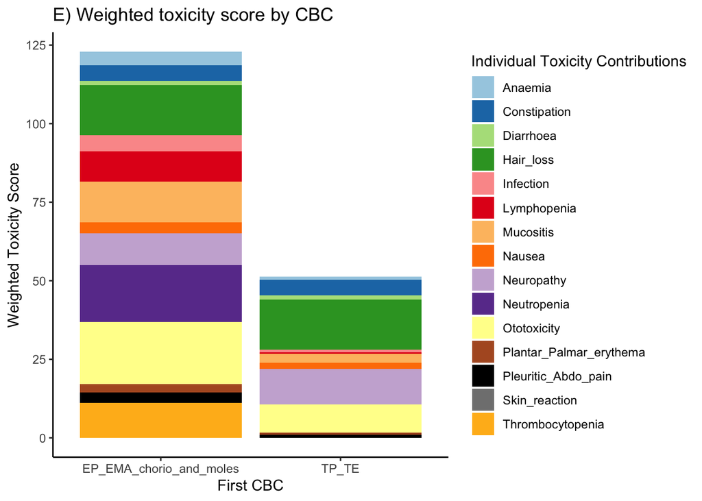

```r
ggsave("Mean_toxicity_burden_by_age_plot.png", plot = Mean_toxicity_burden_by_age_plot, width =6, height = 4, dpi = 300)
EP_EMA_chorio_and_moles_tox_weighted <- as.data.frame(EP_EMA_chorio_and_moles_tox_weighted)
EP_EMA_chorio_and_moles_tox_weighted$Grade_0 <- as.numeric(EP_EMA_chorio_and_moles_tox_weighted$Grade_0)
EP_EMA_chorio_and_moles_tox_weighted$Grade_1 <- as.numeric(EP_EMA_chorio_and_moles_tox_weighted$Grade_1)
EP_EMA_chorio_and_moles_tox_weighted$Grade_2 <- as.numeric(EP_EMA_chorio_and_moles_tox_weighted$Grade_2)
EP_EMA_chorio_and_moles_tox_weighted$Grade_3 <- as.numeric(EP_EMA_chorio_and_moles_tox_weighted$Grade_3)
EP_EMA_chorio_and_moles_tox_weighted$Grade_4 <- as.numeric(EP_EMA_chorio_and_moles_tox_weighted$Grade_4)
EP_EMA_chorio_and_moles_tox_weighted$total_wts_contribution <- rowSums(EP_EMA_chorio_and_moles_tox_weighted %>% select(-Toxicity))

TP_TE_tox_weighted <- as.data.frame(TP_TE_tox_weighted)
TP_TE_tox_weighted$Grade_0 <- as.numeric(TP_TE_tox_weighted$Grade_0)
TP_TE_tox_weighted$Grade_1 <- as.numeric(TP_TE_tox_weighted$Grade_1)
TP_TE_tox_weighted$Grade_2 <- as.numeric(TP_TE_tox_weighted$Grade_2)
TP_TE_tox_weighted$Grade_3 <- as.numeric(TP_TE_tox_weighted$Grade_3)
TP_TE_tox_weighted$Grade_4 <- as.numeric(TP_TE_tox_weighted$Grade_4)
TP_TE_tox_weighted$total_wts_contribution <- rowSums(TP_TE_tox_weighted %>% select (-Toxicity))

WTS_graph_data <- EP_EMA_chorio_and_moles_tox_weighted %>%
  select(Toxicity, total_wts_contribution) %>%
  left_join(
    TP_TE_tox_weighted %>% select(Toxicity, total_wts_contribution),
    by = "Toxicity",
    suffix = c("EP_EMA_chorio_and_moles", "TP_TE")
  )

WTS_graph_data <- WTS_graph_data %>%
  pivot_longer(
    cols = starts_with("total_wts_contribution"),
    names_to = "Group",
    values_to = "Weight"
    ) %>%
  mutate(Group = case_when(
    Group == "total_wts_contributionEP_EMA_chorio_and_moles" ~ "EP_EMA_chorio_and_moles",
    Group == "total_wts_contributionTP_TE" ~ "TP_TE"
  ))

paired_colours <- brewer.pal(12, "Paired")
extra_colours <- c("#000000", "#808080", "#FFB81C")
combined_colours <- c(paired_colours, extra_colours)

WTS_breakdown_plot <- ggplot(WTS_graph_data, aes(x = Group, y = Weight, fill = Toxicity)) +
  geom_bar(stat = "identity") +
  labs(x = "First CBC", y = "Weighted Toxicity Score", fill = "Individual Toxicity Contributions") +
  theme_classic() +
  scale_fill_manual(values = combined_colours) +
  ggtitle("E) Weighted toxicity score by CBC")
print(WTS_breakdown_plot)
```

```r
ggsave("WTS_breakdown_plot.png", plot = WTS_breakdown_plot, height = 4, width = 8, dpi = 300)
```

##4.3 CBC outcomes ####hCG-CR rates

```r
summary(TP_TE_data$hCG_CR)
```

```
## Complete       no
##       12        3
```

```r
summary(TP_TE_refractory_highrisk$hCG_CR)
```

```
## Complete       no
##        7        1
```

```r
summary(TP_TE_refractory_lowrisk$hCG_CR)
```

```
## Complete       no
##        4        1
```

```r
summary(TP_TE_refractory_ultrahighrisk$hCG_CR)
```

```
## Complete       no
##        1        8
```

```r
summary(TP_TE_ultrahighrisk$hCG_CR)
```

```
## Complete       no
##        1        1
```

```r
summary(EP_EMA_chorio_and_moles$hCG_CR)
```

```
## Complete       no
##        5       10
```

```r
summary(EP_EMA_UHR$hCG_CR)
```

```
## Complete       no
##        5        7
```

```r
summary(EP_EMA_refractory_patients$hCG_CR)
```

```
## Complete       no
##        0        3
```

#### Predicitve factors of response

```r
relevel(All_chorio_and_persistent_mole$Histology, "Persistent mole")
```

```
##  [1] Choriocarcinoma Choriocarcinoma Choriocarcinoma Choriocarcinoma
##  [5] Choriocarcinoma Choriocarcinoma Choriocarcinoma Choriocarcinoma
##  [9] Choriocarcinoma Choriocarcinoma Choriocarcinoma Choriocarcinoma
## [13] Choriocarcinoma Choriocarcinoma Choriocarcinoma Choriocarcinoma
## [17] Choriocarcinoma Choriocarcinoma Choriocarcinoma Choriocarcinoma
## [21] Persistent mole Persistent mole Persistent mole Persistent mole
## [25] Persistent mole Persistent mole Persistent mole Persistent mole
## [29] Persistent mole Persistent mole
## Levels: Persistent mole Mixed Choriocarcinoma ETT PSTT
```

```r
relevel(All_chorio_and_persistent_mole$first_platinum_treatment, "TP_TE")
```

```
##  [1] TP_TE  EP_EMA EP_EMA EP_EMA TP_TE  EP_EMA EP_EMA TP_TE  TP_TE  TP_TE
## [11] EP_EMA TP_TE  TP_TE  EP_EMA EP_EMA EP_EMA EP_EMA EP_EMA EP_EMA EP_EMA
## [21] TP_TE  EP_EMA TP_TE  TP_TE  TP_TE  TP_TE  TP_TE  TP_TE  EP_EMA TP_TE
## Levels: TP_TE EP_EMA
```

```r
Combined_response_first_logistic_regression <- glm(hCG_CR ~
                                                     Risk.score.at.diagnosis +
                                                     Antecedent.pregnancy.interval..months. +
                                                     First_platinum_cycles +
                                                     first_platinum_treatment,
                                                   family = binomial,
                                                   data = All_chorio_and_persistent_mole)

summary(Combined_response_first_logistic_regression)
```

```
##
## Call:
## glm(formula = hCG_CR ~ Risk.score.at.diagnosis + Antecedent.pregnancy.interval..months. +
##     First_platinum_cycles + first_platinum_treatment, family = binomial,
##     data = All_chorio_and_persistent_mole)
##
## Coefficients:
##                                        Estimate Std. Error z value Pr(>|z|)
## (Intercept)                            -0.38034    1.69564  -0.224    0.823
## Risk.score.at.diagnosis                -0.02842    0.13881  -0.205    0.838
## Antecedent.pregnancy.interval..months. -0.01293    0.02437  -0.531    0.596
## First_platinum_cycles                  -0.40402    0.34034  -1.187    0.235
## first_platinum_treatmentEP_EMA          3.94792    1.83048   2.157    0.031 *
## ---
## Signif. codes:  0 '***' 0.001 '**' 0.01 '*' 0.05 '.' 0.1 ' ' 1
##
## (Dispersion parameter for binomial family taken to be 1)
##
##     Null deviance: 34.296  on 24  degrees of freedom
## Residual deviance: 23.061  on 20  degrees of freedom
##   (5 observations deleted due to missingness)
## AIC: 33.061
##
## Number of Fisher Scoring iterations: 5
```

```r
BIC(Combined_response_first_logistic_regression)
```

```
## [1] 39.15516
```

```r
logLik(Combined_response_first_logistic_regression)
```

```
## 'log Lik.' -11.53039 (df=5)
```

```r
pR2(Combined_response_first_logistic_regression)
```

```
## fitting null model for pseudo-r2
```

```
##         llh     llhNull          G2    McFadden        r2ML        r2CU
## -11.5303893 -17.1482450  11.2357114   0.3276053   0.3620073   0.4850271
```

[figure not shown]

```r
emm_binomial <- emmeans(
  Combined_response_first_logistic_regression, ~ first_platinum_treatment,
  type = "response"
)
hCG_CR_emmeans_df <- as.data.frame(emm_binomial)

All_chorio_and_persistent_mole <- All_chorio_and_persistent_mole |>
  dplyr::mutate(
    hCG_CR = ifelse(hCG_CR == "Complete", 1, 0)
  )
hCG_CR_predicted_probability_plot <- ggplot() +
  geom_jitter(data = All_chorio_and_persistent_mole, aes(x= first_platinum_treatment, y = hCG_CR, colour = first_platinum_treatment),
              width = 0.1,
              height = 0.1,
              alpha = 0.5,
              size = 1.5) +
  geom_point(data = hCG_CR_emmeans_df, aes (x = first_platinum_treatment, y = prob, colour = first_platinum_treatment),
             size = 3) +
  geom_errorbar(data = hCG_CR_emmeans_df, aes(x = first_platinum_treatment,
             ymin = asymp.LCL,
             ymax = asymp.UCL,
             colour = first_platinum_treatment),
             width = 0.15) +
    labs(
    x = "First CBC",
    y = "Adjusted probability of hCG_CR"
  ) +
  theme_classic() +
  theme(legend.position = "none") +
  ggtitle("Predicted probability of hCG_CR by first CBC")
print(hCG_CR_predicted_probability_plot)
```

```r
ggsave("hCH_CR_predicted_probability_plot.png", plot = hCG_CR_predicted_probability_plot, width =6, height = 4, dpi = 300)
```

##5.0 Extra WTS calculations for discussion

```r
####Extra dataset wts calculations
#Custom toxicity weighting tables must be made due to differing toxicities recorded. As differing toxicities were recorded between the present, and the EMA/CO and MEA datasets, diferent toxicities were omitted from calculations depending on the comparison groups. Details to be found in the methods sections

#New waiting table
Toxicity_weights <- data.frame(
  Toxicity = c("Nausea", "Anaemia", "Neutropenia", "Thrombocytopenia", "Neuropathy", "Hair_loss","Mucositis", "Diarrhoea", "Constipation", "Infection", "Skin_reaction", "Ototoxicity", "Plantar_Palmar_erythema", "Pleuritic_Abdo_pain"),
  Grade_0 = c("0","0","0","0","0","0","0","0","0","0","0","0","0","0"),
  Grade_1 = c("4","2","0","4","8","8","4","4","4","4","0","8","8","8"),
  Grade_2 = c("8","4","0","8","16","16","8","8","8","8","16","32","16","16"),
  Grade_3 = c("32","8","16","32","32","0","32","16","16","32","32","64","32","32"),
  Grade_4 = c("0","32","32","64","64","0","0","32","64","64","64","0","0","0"))
Toxicity_weights <- Toxicity_weights %>%
  arrange(Toxicity)
print(Toxicity_weights)
```

```
##                   Toxicity Grade_0 Grade_1 Grade_2 Grade_3 Grade_4
## 1                  Anaemia       0       2       4       8      32
## 2             Constipation       0       4       8      16      64
## 3                Diarrhoea       0       4       8      16      32
## 4                Hair_loss       0       8      16       0       0
## 5                Infection       0       4       8      32      64
## 6                Mucositis       0       4       8      32       0
## 7                   Nausea       0       4       8      32       0
## 8               Neuropathy       0       8      16      32      64
## 9              Neutropenia       0       0       0      16      32
## 10             Ototoxicity       0       8      32      64       0
## 11 Plantar_Palmar_erythema       0       8      16      32       0
## 12     Pleuritic_Abdo_pain       0       8      16      32       0
## 13           Skin_reaction       0       0      16      32      64
## 14        Thrombocytopenia       0       4       8      32      64
```

```r
write.csv(Toxicity_weights, '/Users/arthurevans/Library/Mobile Documents/com~apple~CloudDocs/Documents/Work/Research stuff/Platinum dataset stuff /Data/Toxicity_weights.csv', row.names = FALSE)
Toxicity_weights$Grade_0 <- as.numeric(Toxicity_weights$Grade_0)
Toxicity_weights$Grade_1 <- as.numeric(Toxicity_weights$Grade_1)
Toxicity_weights$Grade_2 <- as.numeric(Toxicity_weights$Grade_2)
Toxicity_weights$Grade_3 <- as.numeric(Toxicity_weights$Grade_3)
Toxicity_weights$Grade_4 <- as.numeric(Toxicity_weights$Grade_4)


#Applying the weightings to MEA and EMA_CO toxocity spread tables
MEA_tox_weighted <- cbind(
  Toxicity = MEA_tox$Toxicity,
  as.data.frame(Map(`*`,
    MEA_tox%>% select(-Toxicity),
    Toxicity_weights %>% select(-Toxicity))))
MEA_wts <- sum(unlist(MEA_tox_weighted %>% select(-Toxicity)))
print(MEA_wts)
```

```
## [1] 67.974
```

```r
EMA_CO_tox_weighted <- cbind(
  Toxicity = EMA_CO_tox$Toxicity,
  as.data.frame(Map(`*`,
    EMA_CO_tox%>% select(-Toxicity),
    Toxicity_weights %>% select(-Toxicity))))
EMA_CO_wts <- sum(unlist(EMA_CO_tox_weighted %>% select(-Toxicity)))
print(EMA_CO_wts)
```

```
## [1] 108.136
```

```r
#Removing lymphopenia from EP_EMA toxicity dataset
EP_EMA_no_lymphopenia_tox <- EP_EMA_chorio_and_moles_tox_summary_table_reshaped[EP_EMA_chorio_and_moles_tox_summary_table_reshaped$Toxicity != "Lymphopenia", ]

EP_EMA_no_lymphopenia_tox_weighted <- cbind(
  Toxicity = EP_EMA_no_lymphopenia_tox$Toxicity,
  as.data.frame(Map(`*`,
    EP_EMA_no_lymphopenia_tox%>% select(-Toxicity),
    Toxicity_weights %>% select(-Toxicity))))
EP_EMA_no_lymphopenia_wts <- sum(unlist(EP_EMA_no_lymphopenia_tox_weighted %>% select(-Toxicity)))
print(EP_EMA_no_lymphopenia_wts)
```

```
## [1] 113.3333
```

```r
#Removing lymphopenia from TP_TE toxicity dataset
TP_TE_no_lymphopenia_tox <- TP_TE_tox_summary_table_reshaped[TP_TE_tox_summary_table_reshaped$Toxicity != "Lymphopenia", ]

TP_TE_no_lymphopenia_tox_weighted <- cbind(
  Toxicity = TP_TE_no_lymphopenia_tox$Toxicity,
  as.data.frame(Map(`*`,
    TP_TE_no_lymphopenia_tox%>% select(-Toxicity),
    Toxicity_weights %>% select(-Toxicity))))
TP_TE_no_lymphopenia_wts <- sum(unlist(TP_TE_no_lymphopenia_tox_weighted %>% select(-Toxicity)))
print(TP_TE_no_lymphopenia_wts)
```

```
## [1] 50.8
```